# STATS506-HW3-JunjieZeng

Author

Junjie Zeng

# STATS506 Problem Set #3

## Repository

https://github.com/JunjieZeng1/STATS-506.git

## Problem 1

### a

```r
# Load packages
library(haven)
library(dplyr)
library(knitr)
library(tidyr)
library(broom)
library(pscl)
library(DescTools)
```

```r
# Load data
vix_d <- read_xpt("/Users/junjiezeng/Desktop/git/STATS506/HW3/VIX_D.XPT")
demo_d <- read_xpt("/Users/junjiezeng/Desktop/git/STATS506/HW3/DEMO_D.XPT")
```

```r
# Merging data
df <- data.frame(inner_join(vix_d, demo_d, by = "SEQN"))
```

```r
# Check sample size is 6980
nrow(df)
```

```
[1] 6980
```

### b

```r
# Create age categories
df <- df |>
  mutate(age_levels = cut(RIDAGEYR, breaks = seq(0, 90, by = 10), right = FALSE,
                          labels = c("0-9", "10-19", "20-29", "30-39", "40-49",
                                      "50-59", "60-69", "70-79", "80+")))
```

```r
glass_prop <- df |>
  select(c(VIQ220, age_levels)) |>
  filter(VIQ220 %in% c(1,2)) |>
  group_by(age_levels) |>
  summarize(glass = sum(VIQ220 == 1),
            total = n(),
            proportion = sum(VIQ220 == 1) / total)
```

```r
# Create a table using kable
kable(glass_prop,
      format = "html",
      caption = "Proportion of Wearing Glasses/Contact Lenses",
      col.names = c("Age", "Wearing Glasses/Contacts", "Total", "Proportion"),
      digits = 3)
```

Proportion of Wearing Glasses/Contact Lenses

| Age | Wearing Glasses/Contacts | Total | Proportion |
| --- | --- | --- | --- |
| 10-19 | 670 | 2088 | 0.321 |
| 20-29 | 306 | 937 | 0.327 |
| 30-39 | 269 | 750 | 0.359 |
| 40-49 | 286 | 773 | 0.370 |
| 50-59 | 335 | 609 | 0.550 |
| 60-69 | 392 | 630 | 0.622 |
| 70-79 | 299 | 447 | 0.669 |
| 80+ | 208 | 311 | 0.669 |

### c

```r
# Clean the data
df_cleaned_for_pc <- df |>
  select(c(VIQ220, INDFMPIR, RIDAGEYR, RIAGENDR, RIDRETH1)) |>
  drop_na(VIQ220) |>
  mutate(is_glass = ifelse(VIQ220 == 1, 1, 0),
         gender = as.factor(RIAGENDR),
         race = as.factor(RIDRETH1),
         age = RIDAGEYR,
         PIR = INDFMPIR)
```

```r
# Model 1
model1 <- glm(is_glass ~ age, data = df_cleaned_for_pc, family = "binomial")

# Model 2
model2 <- glm(is_glass ~ age + race + gender, data = df_cleaned_for_pc, family = "binomial")

# Model 3
model3 <- glm(is_glass ~ age + race + gender + PIR, data = df_cleaned_for_pc, family = "binomial")
```

```r
# Create a function to get model summary
model_summary <- function(lg) {
  odds_ratio <- exp(coef(lg))
  pseudo_r2 <- PseudoR2(lg)["McFadden"]
  aic <- lg$aic
  sample_size <- nrow(lg$model)

  return(list(odds_ratio = odds_ratio,
              pseudo_r2 = pseudo_r2,
              AIC = aic,
              sample_size = sample_size))
}

# Use the functions to get summaries
model1_summary <- model_summary(model1)
model2_summary <- model_summary(model2)
model3_summary <- model_summary(model3)
```

```r
# Create a raw summary table
table_models <- data.frame(
  Model = c("Age",
            "Age, Race, Gender",
            "Age, Race, Gender, PIR"),

  Odds_Ratio_Intercept = c(round(model1_summary$odds_ratio[1], 2),
                           round(model2_summary$odds_ratio[1], 2),
                           round(model3_summary$odds_ratio[1], 2)),

  Odds_Ratio_Age = c(round(model1_summary$odds_ratio[2], 2),
                     round(model2_summary$odds_ratio[2], 2),
                     round(model3_summary$odds_ratio[2], 2)),

  Odds_Ratio_Female = c(round(model1_summary$odds_ratio[7], 2),
                        round(model2_summary$odds_ratio[7], 2),
                        round(model3_summary$odds_ratio[7], 2)),

  Odds_Ratio_Other_Hispanic = c(round(model1_summary$odds_ratio[3], 2),
                                round(model2_summary$odds_ratio[3], 2),
                                round(model3_summary$odds_ratio[3], 2)),

  Odds_Ratio_Non_Hispanic_White = c(round(model1_summary$odds_ratio[4], 2),
                                    round(model2_summary$odds_ratio[4], 2),
                                    round(model3_summary$odds_ratio[4], 2)),

  Odds_Ratio_Non_Hispanic_Black = c(round(model1_summary$odds_ratio[5], 2),
                                    round(model2_summary$odds_ratio[5], 2),
                                    round(model3_summary$odds_ratio[5], 2)),

  Odds_Ratio_Other_Race = c(round(model1_summary$odds_ratio[6], 2),
                                  round(model2_summary$odds_ratio[6], 2),
                                  round(model3_summary$odds_ratio[6], 2)),

  Odds_Ratio_PIR = c(round(model1_summary$odds_ratio[8], 2),
                     round(model2_summary$odds_ratio[8], 2),
                     round(model3_summary$odds_ratio[8], 2)),

  Sample_Size = c(model1_summary$sample_size,
                  model2_summary$sample_size,
                  model3_summary$sample_size),

  Pseudo_R2 = c(round(model1_summary$pseudo_r2, 4),
                round(model2_summary$pseudo_r2, 4),
                round(model3_summary$pseudo_r2, 4)),

  AIC = c(model1_summary$AIC,
          model2_summary$AIC,
          model3_summary$AIC)
)
```

```r
# Make the table look nicer
kable(table_models,
      format = "html",
      col.names = c("Model",
                    "Odds Ratio Intercept",
                    "Odds Ratio Age",
                    "Odds Ratio Female",
                    "Odds Ratio Other Hispanic",
                    "Odds Ratio Non-Hispanic White",
                    "Odds Ratio Non-Hispanic Black",
                    "Odds Ratio Other Race",
                    "Odds Ratio PIR",
                    "Sample Size",
                    "Pseudo R-squared",
                    "AIC"))
```

| Model | Odds Ratio Intercept | Odds Ratio Age | Odds Ratio Female | Odds Ratio Other Hispanic | Odds Ratio Non-Hispanic White | Odds Ratio Non-Hispanic Black | Odds Ratio Other Race | Odds Ratio PIR | Sample Size | Pseudo R-squared | AIC |
| --- | --- | --- | --- | --- | --- | --- | --- | --- | --- | --- | --- |
| Age | 0.28 | 1.02 | NA | NA | NA | NA | NA | NA | 6547 | 0.0498 | 8477.679 |
| Age, Race, Gender | 0.16 | 1.02 | 1.65 | 1.17 | 1.95 | 1.30 | 1.92 | NA | 6547 | 0.0719 | 8289.925 |
| Age, Race, Gender, PIR | 0.13 | 1.02 | 1.67 | 1.12 | 1.65 | 1.23 | 1.71 | 1.12 | 6249 | 0.0734 | 7912.077 |

### d

```r
# Summary model 3
summary(model3)
```

```
Call:
glm(formula = is_glass ~ age + race + gender + PIR, family = "binomial",
    data = df_cleaned_for_pc)

Deviance Residuals:
    Min       1Q   Median       3Q      Max
-1.8388  -0.9889  -0.7191   1.1205   1.9351

Coefficients:
             Estimate Std. Error z value Pr(>|z|)
(Intercept) -2.017050   0.087797 -22.974  < 2e-16 ***
age          0.022202   0.001295  17.146  < 2e-16 ***
race2        0.117483   0.168257   0.698 0.485030
race3        0.502239   0.075116   6.686 2.29e-11 ***
race4        0.208817   0.079205   2.636 0.008379 **
race5        0.534345   0.140139   3.813 0.000137 ***
gender2      0.515109   0.054298   9.487  < 2e-16 ***
PIR          0.113427   0.017699   6.409 1.47e-10 ***
---
Signif. codes:  0 '***' 0.001 '**' 0.01 '*' 0.05 '.' 0.1 ' ' 1

(Dispersion parameter for binomial family taken to be 1)

    Null deviance: 8521.3  on 6248  degrees of freedom
Residual deviance: 7896.1  on 6241  degrees of freedom
  (298 observations deleted due to missingness)
AIC: 7912.1

Number of Fisher Scoring iterations: 4
```

To test whether the odds of men and women being wears of glasess/contact lenses for distance vision differs, we only need to look at the summary table of the model 3. On the gender2 (female) row, a hypothesis test was automatically done by R telling us whether there is a difference between the odds. As the table shown, the z-value is 9.487, and the p-value is < 2e-16, which is significantly less than the significance level 0.05, rejecting the null hypothesis that the odds of men and women being wears of glasess/contact lenses for distance vision do not differ. We have enough evidence to conclude that they differ.

To test whether the proportion of wearers of glasses/contact lenses for distance vision differs between men and women, we shall use a chi-squared test.

```r
# Perform chi-squared test
chisq_test <- chisq.test(table(df_cleaned_for_pc$gender, df_cleaned_for_pc$is_glass))
chisq_test
```

```
    Pearson's Chi-squared test with Yates' continuity correction

data:  table(df_cleaned_for_pc$gender, df_cleaned_for_pc$is_glass)
X-squared = 70.593, df = 1, p-value < 2.2e-16
```

From the summary above, the test statistic is 70.593 and the degree of freedom is 1. The p-value for the Chi-squared test is < 2.2e-16. So we reject the null hypothesis that the proportions of men and women being wears of glasess/contact lenses for distance vision do not differ. We have enough evidence to conclude that the proportions differ.

### Reference for Problem 1

#### Calculate odds ratio

https://stackoverflow.com/questions/41384075/r-calculate-and-interpret-odds-ratio-in-logistic-regression/

#### Calculate pseudo-R^2 https://search.r-project.org/CRAN/refmans/DescTools/html/PseudoR2.html

## Problem 2

### a

```r
# Packages
library(DBI)
library(RSQLite)
```

```r
# Import the SQLite database of the sakila data
sakila <- dbConnect(RSQLite::SQLite(), "/Users/junjiezeng/Desktop/git/STATS506/HW3/sakila_master.db")
sakila
```

```
<SQLiteConnection>
  Path: /Users/junjiezeng/Desktop/git/STATS506/HW3/sakila_master.db
  Extensions: TRUE
```

```r
dbListTables(sakila)
```

```
 [1] "actor"                  "address"                "category"
 [4] "city"                   "country"                "customer"
 [7] "customer_list"          "film"                   "film_actor"
[10] "film_category"          "film_list"              "film_text"
[13] "inventory"              "language"               "payment"
[16] "rental"                 "sales_by_film_category" "sales_by_store"
[19] "staff"                  "staff_list"             "store"
```

```r
dbListFields(sakila, 'film')
```

```
 [1] "film_id"              "title"                "description"
 [4] "release_year"         "language_id"          "original_language_id"
 [7] "rental_duration"      "rental_rate"          "length"
[10] "replacement_cost"     "rating"               "special_features"
[13] "last_update"
```

```r
# What year is the oldest movie from, and how many movies were released in that year
dbGetQuery(sakila, "
SELECT release_year, COUNT(*) AS Num_films
  FROM film
  WHERE release_year = (SELECT MIN(release_year) FROM film)
")
```

```
  release_year Num_films
1         2006      1000
```

### b

```r
# Package
library(tidyverse)
```

```r
# Method 1
df <- dbGetQuery(sakila, '
SELECT f.film_id, fcc.category_id, fcc.name
  FROM film AS f
      INNER JOIN
      (SELECT c.category_id, c.name, fc.film_id
         FROM category as c
              INNER JOIN film_category AS fc ON c.category_id = fc.category_id) AS fcc ON f.film_id = fcc.film_id
')

df |>
  group_by(name) |>
  summarize(total = n()) |>
  arrange(total) |>
  head(1)
```

```
# A tibble: 1 × 2
  name  total
  <chr> <int>
1 Music    51
```

Music movie is the least common in the data, there are 51 movies of this genre.

```r
# Method 2
dbGetQuery(sakila, '
SELECT fcc.name, COUNT(*) AS count
  FROM film AS f
    INNER JOIN
      (SELECT c.category_id, c.name, fc.film_id
         FROM category as c
              INNER JOIN film_category AS fc ON c.category_id = fc.category_id) AS fcc ON f.film_id = fcc.film_id
  GROUP BY fcc.name
  ORDER BY count
  LIMIT 1
')
```

```
   name count
1 Music    51
```

Same result as the method 1. Music movie is the least common in the data, there are 51 movies of this genre.

### c

```r
# Method 1
df2 <- dbGetQuery(sakila, '
SELECT cocia.country
  FROM customer AS c
    INNER JOIN
    (SELECT a.address_id, co.country
       FROM address AS a
         INNER JOIN city AS ci ON a.city_id = ci.city_id
         INNER JOIN country AS co ON ci.country_id = co.country_id) AS cocia
     ON cocia.address_id = c.address_id
')

df2 |>
  group_by(country) |>
  summarize(total = n()) |>
  filter(total == 13)
```

```
# A tibble: 2 × 2
  country   total
  <chr>     <int>
1 Argentina    13
2 Nigeria      13
```

Argentina and Nigeria are countries have exactly 13 customers.

```r
# Method 2
dbGetQuery(sakila, '
SELECT cocia.country, COUNT(*) AS customer_count
  FROM customer AS c
    INNER JOIN
    (SELECT a.address_id, co.country
       FROM address AS a
         INNER JOIN city AS ci ON a.city_id = ci.city_id
         INNER JOIN country AS co ON ci.country_id = co.country_id) AS cocia
     ON cocia.address_id = c.address_id
  GROUP BY cocia.country
  HAVING COUNT(*) = 13
')
```

```
    country customer_count
1 Argentina             13
2   Nigeria             13
```

Same as the method 1, Argentina and Nigeria are countries have exactly 13 customers.

## Problem 3

### a

```r
# Load data
data <- read.csv("/Users/junjiezeng/Desktop/git/STATS506/HW3/us-500.csv")
head(data)
```

```
  first_name last_name           company_name              address        city
1      James      Butt      Benton, John B Jr   6649 N Blue Gum St New Orleans
2  Josephine   Darakjy  Chanay, Jeffrey A Esq  4 B Blue Ridge Blvd    Brighton
3        Art    Venere    Chemel, James L Cpa 8 W Cerritos Ave #54  Bridgeport
4      Lenna  Paprocki Feltz Printing Service          639 Main St   Anchorage
5    Donette    Foller    Printing Dimensions         34 Center St    Hamilton
6     Simona   Morasca    Chapman, Ross E Esq         3 Mcauley Dr     Ashland
      county state   zip       phone1       phone2
1    Orleans    LA 70116 504-621-8927 504-845-1427
2 Livingston    MI 48116 810-292-9388 810-374-9840
3 Gloucester    NJ  8014 856-636-8749 856-264-4130
4  Anchorage    AK 99501 907-385-4412 907-921-2010
5     Butler    OH 45011 513-570-1893 513-549-4561
6    Ashland    OH 44805 419-503-2484 419-800-6759
                          email                                 web
1               jbutt@gmail.com        http://www.bentonjohnbjr.com
2 josephine_darakjy@darakjy.org    http://www.chanayjeffreyaesq.com
3                art@venere.org      http://www.chemeljameslcpa.com
4         lpaprocki@hotmail.com http://www.feltzprintingservice.com
5        donette.foller@cox.net   http://www.printingdimensions.com
6            simona@morasca.com      http://www.chapmanrosseesq.com
```

```r
# Get proportion by adding a binary column and calculate the mean
data |>
  select(email) |>
  mutate(is_dotcom = ifelse(str_detect(email, ".com"), 1, 0)) |>
  summarize(mean(is_dotcom))
```

```
  mean(is_dotcom)
1           0.734
```

So, 73.4 percent of email addresses are hosted at a domain with TLD “.com”.

### b

```r
# Check for non-alphanumeric characters
# First find non-alphanumeric characters other than @ and .
# then find ones with multiple @ and .
data |>
  mutate(non_an = str_detect(email, "[^a-zA-Z0-9@.]") |
                     str_count(email, "@") > 1 |
                     str_count(email, "\\.") > 1 )|>
  summarize(proportion = mean(non_an))
```

```
  proportion
1      0.506
```

So, 50.6 percent of email addresses have at least one non alphanumeric character in them.

### c

```r
# Check any na values in phone1, phone2
anyNA(data$phone1)
```

```
[1] FALSE
```

```r
anyNA(data$phone2)
```

```
[1] FALSE
```

```r
# Check whether area_code same for all phone1 and phone2
all(substr(data$phone1, 1, 3) == substr(data$phone2, 1, 3))
```

```
[1] TRUE
```

```r
# Since area_code same for all phone1 and phone2,
# its enough to look at phone1 only
data |>
  mutate(area_code = substr(phone1, 1, 3)) |>
  group_by(area_code) |>
  summarize(total = n()) |>
  arrange(desc(total)) |>
  head(5)
```

```
# A tibble: 5 × 2
  area_code total
  <chr>     <int>
1 973          18
2 212          14
3 215          14
4 410          14
5 201          12
```

The top 5 most common area codes amongst all phone numbers are 973, 212, 215, 410, and 201.

### d

```r
# Look at some data
data$address |>
  head(20)
```

```
 [1] "6649 N Blue Gum St"    "4 B Blue Ridge Blvd"   "8 W Cerritos Ave #54"
 [4] "639 Main St"           "34 Center St"          "3 Mcauley Dr"
 [7] "7 Eads St"             "7 W Jackson Blvd"      "5 Boston Ave #88"
[10] "228 Runamuck Pl #2808" "2371 Jerrold Ave"      "37275 St  Rt 17m M"
[13] "25 E 75th St #69"      "98 Connecticut Ave Nw" "56 E Morehead St"
[16] "73 State Road 434 E"   "69734 E Carrillo St"   "322 New Horizon Blvd"
[19] "1 State Route 27"      "394 Manchester Blvd"
```

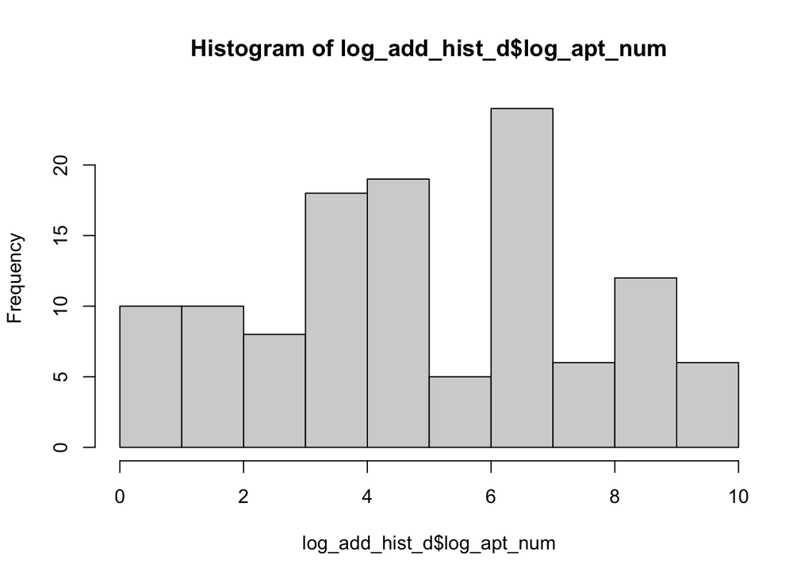

```r
# Extract apartment numbers and create a histogram
log_add_hist_d <- data |>
  select(address) |>
  # Get the number at end, take the log
  mutate(apt_num = as.integer(str_extract(address, "[0-9]+$")),
         log_apt_num = log(apt_num))|>
  filter(!is.na(apt_num) & !is.na(log_apt_num))

hist(log_add_hist_d$log_apt_num)
```

### e

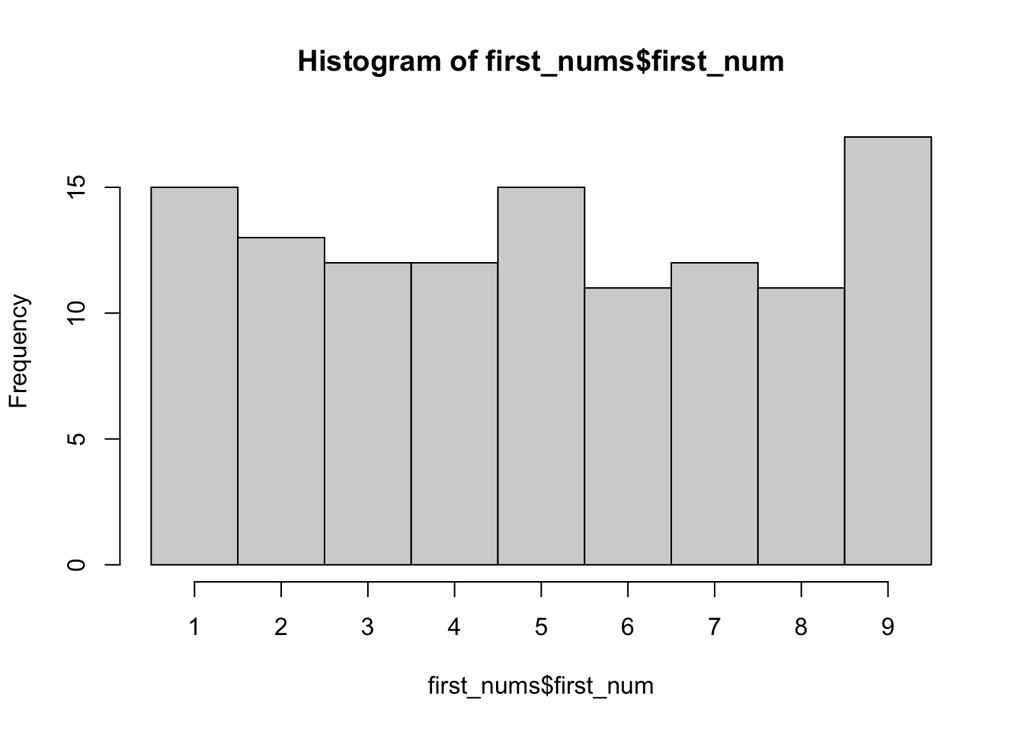

```r
first_nums <- log_add_hist_d |>
  select(apt_num) |>
  mutate(first_num = as.integer(substr(as.character(apt_num), 1, 1)))

# Create the histogram
hist(first_nums$first_num,
     breaks = seq(0.5, 9.5, by = 1),
     xaxt = "n")

axis(1, at = 1:9, labels = 1:9)
```

The histogram suggests a uniform distribution, which does not appear to follow Benford’s law. No, the apartment numbers would not pass as real data.